# Tidy TuesdayWeek 14

Tidy Tuesday is a data project hosted every week by the [R for Data Science learning community.](https://github.com/rfordatascience/tidytuesday) Anyone is welcome to participate, and are encouraged to colloborate and share their findings on Twitter with the [R4DS community](https://twitter.com/R4DScommunity).This week we are examining global life expectancy from [this article](https://ourworldindata.org/life-expectancy).

## Data Cleaning

In order to use the maps library built in mapping data, the country names had to match one another in order to be joined correctly.

```r
life_exp$country <- ifelse(life_exp$country == "United States", "USA", life_exp$country)
life_exp$country <- ifelse(life_exp$country == "Democratic Republic of Congo", "Democratic Republic of the Congo", life_exp$country)
life_exp$country <- ifelse(life_exp$country == "Cote d'Ivoire", "Ivory Coast", life_exp$country)
life_exp$country <- ifelse(life_exp$country == "Congo", "Republic of Congo", life_exp$country)
life_exp$country <- ifelse(life_exp$country == "United States", "USA", life_exp$country)
life_exp$country <- ifelse(life_exp$country == "United Kingdom", "UK", life_exp$country)
life_exp$country <- ifelse(life_exp$country == "Serbia (including Kosovo)", "Serbia", life_exp$country)
```

# Making a Table to Highlight Global Percent Change

I thought it would be interesting to examine which countries saw the biggest and the smallest improvements in life expectancy. I first separated the data into two new data frames, one for the year 1950 and opne for the year 2015. I then joined the two together and found the difference for every country’s change in life expectancy and then also calculated the percent change.

```r
life_1950 <- life_exp %>%
  group_by(country) %>%
  filter(year == 1950)

life_2015 <- life_exp %>%
  group_by(country) %>%
  filter(year == 2015)

exp_change <- life_1950 %>%
  bind_cols(life_2015) %>%
  mutate(change = round(life_expectancy1 - life_expectancy, 2)) %>%
  mutate(percent_change = round(change / life_expectancy * 100, 2)) %>%
  arrange(desc(percent_change))

ten_highest <- exp_change %>%
  ungroup() %>%
  select(country, change, percent_change) %>%
  top_n(10)
ten_lowest <- exp_change %>%
  ungroup() %>%
  select(country, change, percent_change) %>%
  top_n(-10) %>%
  arrange(percent_change)
top_10 <- bind_cols(ten_highest, ten_lowest)

top_10$change <- paste("+", top_10$change)
top_10$change1 <- paste("+", top_10$change1)
top_10$percent_change <- paste0(top_10$percent_change, "%")
top_10$percent_change1 <- paste0(top_10$percent_change1, "%")

top_10 %>%
  kable(caption = "Top Ten Countries with the Largest and Smallest Percent Change in Life Expectancy (1950 - 2015)",
        col.names = c("Country", "Difference in Years", "Largest Percent Change",
                      "Country", "Difference in Years", "Smallest Percent Change")) %>%
  kable_styling()
```

Top Ten Countries with the Largest and Smallest Percent Change in Life Expectancy (1950 - 2015)

Country

Difference in Years

Largest Percent Change

Country

Difference in Years

Smallest Percent Change

North Korea

- 41.74

140.46%

Norway

- 9.68

13.38%

Timor

- 39.61

136.8%

Guyana

- 8.12

13.9%

Afghanistan

- 35.75

129.83%

Denmark

- 10.12

14.36%

Maldives

- 42.89

125.59%

Netherlands

- 10.3

14.42%

Oman

- 42.61

124.62%

Iceland

- 10.92

15.24%

Bhutan

- 38.15

120.46%

Sweden

- 10.97

15.38%

Mali

- 31.07

117.65%

USA

- 11.04

16.19%

South Sudan

- 29.6

110.79%

Paraguay

- 10.34

16.49%

Nepal

- 35.86

105.39%

Northern America

- 11.33

16.61%

Gambia

- 31.26

105.28%

Uruguay

- 11.54

17.54%

This table is the final result. To me, this table is super encouraging because no country had decreases in life expectancy. The countries that changed the most are traditionally considered as “developing” countries. This speaks volumes in terms of improvements in available health care and overall growth as countries. The majority of the countries with the smallest percent change are countries with solid health care, so it makes sense that they didnt see large increases in this period. This table is neat to show the overall picture, but I think it’s weakness lies in the sense that it doesn’t show what happened betweened these years, just the two end points.

# Creating a Choropleth World Map

Using the data from above, I wanted to create a global map showing these increases to help visualize the entire picture, not just a select number of countries.

## Creating the map

Nothing fancy here, I just joined the mapping data with our dataset.

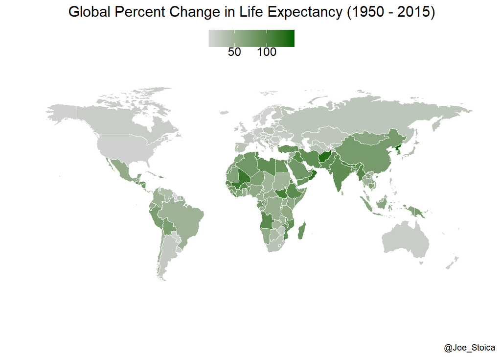

```r
map.world <- map_data("world")
map.world <- left_join(map.world, exp_change, by = c("region" = "country"))

ggplot() +
  geom_polygon(data = map.world,
               aes(x = long,
                   y = lat,
                   group = group,
                   fill = percent_change),
               color = "white",
               size = 0.25) +
  scale_fill_gradient(low = "light grey",
                      high = "dark green",
                      na.value = "white",
                      guide = "colorbar") +
  labs(title = "Global Percent Change in Life Expectancy (1950 - 2015)",
       caption = "@Joe_Stoica") +
  theme(plot.title = element_text(hjust = 0.5, size = 15),
        legend.title = element_blank(),
        legend.position = "top",
        legend.text = element_text(size = 12),
        panel.background = element_blank(),
        plot.background = element_blank(),
        panel.grid = element_blank(),
        axis.text = element_blank(),
        axis.title = element_blank(),
        axis.ticks = element_blank()
        )
```

# Animating Life Expectancy Across the Entire Time Period

I have never worked with gganimate before, so I thought this would be a good time to learn how to use it! Note: As of 7/15/18, I can no longer run this code due to gganimate being completely redone. Once the final version is published to CRAN, I will come back and make this run again. Here is a tweet showing the final gif though!

> (1/2) Here is my second [#tidytuesday](https://twitter.com/hashtag/tidytuesday?src=hash&ref_src=twsrc%5Etfw) submission! This is my first time using gganimate, and I'm happy with the results! [#dataviz](https://twitter.com/hashtag/dataviz?src=hash&ref_src=twsrc%5Etfw) [#rstats](https://twitter.com/hashtag/rstats?src=hash&ref_src=twsrc%5Etfw) [#ggplot](https://twitter.com/hashtag/ggplot?src=hash&ref_src=twsrc%5Etfw) [pic.twitter.com/AGGa6SWJgv](https://t.co/AGGa6SWJgv)

> — Joe Stoica (@Joe_Stoica) [July 4, 2018](https://twitter.com/Joe_Stoica/status/1014596814719406080?ref_src=twsrc%5Etfw)

```r
p <- ggplot() +
  geom_density(data = life_exp %>% filter(year >= 1950),
               fill = "#5e8c9e",
               aes(life_expectancy,
                   frame = year,
                   cumulative = FALSE)) +
  theme_fivethirtyeight() +
  labs(subtitle = "Global Changes in Life Expectancy (1950 -2015)",
       caption = "@Joe_Stoica") +
  theme(axis.title = element_text())+
  xlab("Life Expectancy") +
  ylab("Density")

#gganimate(p, interval = 0.1)
```